# Graphical Testing

```r
library(gsDesign)
library(gMCPLite)
library(dplyr)
library(kableExtra)
```

## Multiplicity diagram for hypothesis testing

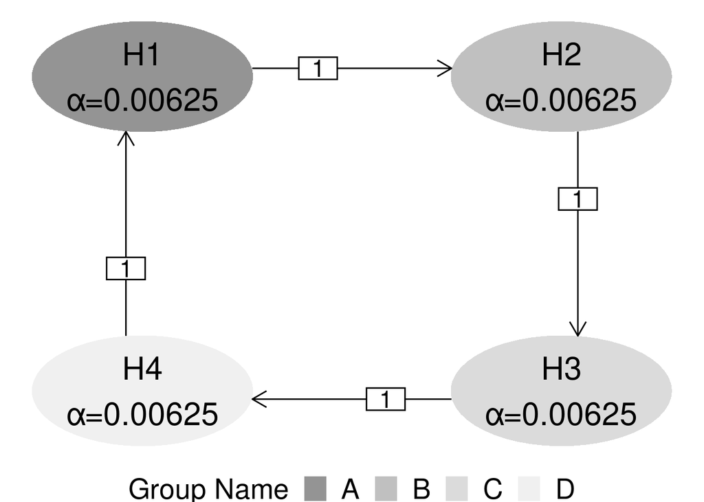

```r
nameHypotheses <- c("H1", "H2", "H3", "H4")
alphaHypotheses <- c(0.00625, 0.00625, 0.00625, 0.00625)
FWER <- sum(alphaHypotheses)
GroupHypotheses <- c("A", "B", "C", "D")
n_hypo <- 4
m <- matrix(c(0, 0, 0, 1, 1, 0, 0, 0, 0, 1, 0, 0, 0, 0, 1, 0), nrow = n_hypo)

h <- hGraph(
  nHypotheses     = n_hypo,
  nameHypotheses  = nameHypotheses,
  alphaHypotheses = alphaHypotheses ,
  m               = m,
  fill            = factor(GroupHypotheses, levels = unique(GroupHypotheses)),
  palette         = c("#4D4D4D99", "#96969699", "#C3C3C399", "#E6E6E699"),
  labels          = unique(GroupHypotheses),
  legend.name     = "Group Name",
  legend.position = "bottom",
  halfWid         = 0.75,
  halfHgt         = 0.5,
  trhw            = 0.13,
  trhh            = 0.1,
  trprop          = 0.33,
  digits          = 5,
  trdigits        = 4,
  size            = 8,
  boxtextsize     = 6,
  legend.textsize = 20,
  arrowsize       = 0.035,
  offset          = 0.15,
  x               = NULL,
  y               = NULL,
  wchar           = "\u03b1"
)

plot(h)
```

## Original design for each hypothesis

```r
endpoint<-c("gsd", "fix", "fix", "fix")
k <- list(3, NULL, NULL, NULL)
test.type <- list(4, NULL, NULL, NULL)
alpha <- list(0.00625, NULL, NULL, NULL)
beta <- list(0.1, NULL, NULL, NULL)
astar <- list(0, NULL, NULL, NULL)
timing <- list(c(0.333333333333333, 0.666666666666667, 1), NULL, NULL, NULL)
sfu <- list(function (alpha, t, param = NULL)
{
    checkScalar(alpha, "numeric", c(0, Inf), c(FALSE, FALSE))
    checkVector(t, "numeric", c(0, Inf), c(TRUE, FALSE))
    if (is.null(param) || param < 0.005 || param > 20)
        param <- 1
    checkScalar(param, "numeric", c(0.005, 20), c(TRUE, TRUE))
    t[t > 1] <- 1
    if (param == 1) {
        rho <- 1
        txt <- "Lan-DeMets O'Brien-Fleming approximation"
        parname <- "none"
    }
    else {
        rho <- param
        txt <- "Generalized Lan-DeMets O'Brien-Fleming"
        parname <- "rho"
    }
    z <- -qnorm(alpha/2)
    x <- list(name = txt, param = param, parname = parname, sf = sfLDOF, spend = 2 * (1 - pnorm(z/t^(rho/2))), bound = NULL, prob = NULL)
    class(x) <- "spendfn"
    x
}, NULL, NULL, NULL)
sfupar <- list(1, NULL, NULL, NULL)
sfl <- list(function (alpha, t, param = NULL)
{
    checkScalar(alpha, "numeric", c(0, Inf), c(FALSE, FALSE))
    checkVector(t, "numeric", c(0, Inf), c(TRUE, FALSE))
    if (is.null(param) || param < 0.005 || param > 20)
        param <- 1
    checkScalar(param, "numeric", c(0.005, 20), c(TRUE, TRUE))
    t[t > 1] <- 1
    if (param == 1) {
        rho <- 1
        txt <- "Lan-DeMets O'Brien-Fleming approximation"
        parname <- "none"
    }
    else {
        rho <- param
        txt <- "Generalized Lan-DeMets O'Brien-Fleming"
        parname <- "rho"
    }
    z <- -qnorm(alpha/2)
    x <- list(name = txt, param = param, parname = parname, sf = sfLDOF, spend = 2 * (1 - pnorm(z/t^(rho/2))), bound = NULL, prob = NULL)
    class(x) <- "spendfn"
    x
}, NULL, NULL, NULL)
sflpar <- list(1, NULL, NULL, NULL)
lambdaC <- list(0.115524530093324, NULL, NULL, NULL)
hr <- list(0.6, NULL, NULL, NULL)
hr0 <- list(1, NULL, NULL, NULL)
etaC <- list(0.01, NULL, NULL, NULL)
etaE <- list(0.01, NULL, NULL, NULL)
gamma <- list(c(10.9538819917591, 21.9077639835181, 32.8616459752772, 43.8155279670363), NULL, NULL, NULL)
R <- list(c(2, 2, 2, 6), NULL, NULL, NULL)
S <- list(NULL, NULL, NULL, NULL)
T <- list(18, NULL, NULL, NULL)
minfup <- list(6, NULL, NULL, NULL)
ratio <- list(1, NULL, NULL, NULL)

gsDlist<-list()
gsDlist <- sapply(1:n_hypo, function(i) if (endpoint[i]=='fix'){NULL}else {
  gsDesign::gsSurv(
        k = k[[i]],
        test.type = test.type[[i]],
        alpha = alpha[[i]],
        beta = beta[[i]],
        astar = astar[[i]],
        timing = timing[[i]],
        sfu = sfu[[i]],
        sfupar = sfupar[[i]],
        sfl = sfl[[i]],
        sflpar = sflpar[[i]],
        lambdaC = lambdaC[[i]],
        hr = hr[[i]],
        hr0 = hr0[[i]],
        eta = etaC[[i]],
        etaE = etaE[[i]],
        gamma = gamma[[i]],
        R = R[[i]],
        S = S[[i]],
        T = T[[i]],
        minfup = minfup[[i]],
        ratio = ratio[[i]])
})
for (i in 1:n_hypo) {
  cat("###", paste(nameHypotheses[i], " \n"))
  d <- gsDlist[[i]]
  # If not group sequential for this hypothesis, print the max alpha allocated
  # and the nominal p-value
  if (is.null(d)) {
    cat(paste0(nameHypotheses[i], " is fixed sample size design."))
    cat("\n\n")
  }
  # For group sequential tests, print max alpha allocated and
  # corresponding group sequential bounds
  if (!is.null(gsDlist[[i]])) {
    tab <- gsDesign::gsBoundSummary(gsDlist[[i]])
    rownames(tab) <- 1:nrow(tab)
    kable(tab, caption = paste0("Design for ", nameHypotheses[i]), row.names = FALSE) %>% kable_styling() %>% cat()
    cat("\n\n")
    }
}
```

### H1

Design for H1

| Analysis | Value | Efficacy | Futility |
| --- | --- | --- | --- |
| IA 1: 33% | Z | 4.5935 | -0.3889 |
| N: 292 | p (1-sided) | 0.0000 | 0.6513 |
| Events: 77 | ~HR at bound | 0.3487 | 1.0933 |
| Month: 10 | P(Cross) if HR=1 | 0.0000 | 0.3487 |
|  | P(Cross) if HR=0.6 | 0.0091 | 0.0044 |
| IA 2: 67% | Z | 3.1521 | 1.4347 |
| N: 396 | p (1-sided) | 0.0008 | 0.0757 |
| Events: 153 | ~HR at bound | 0.5998 | 0.7924 |
| Month: 13 | P(Cross) if HR=1 | 0.0008 | 0.9251 |
|  | P(Cross) if HR=0.6 | 0.5018 | 0.0440 |
| Final | Z | 2.5129 | 2.5129 |
| N: 396 | p (1-sided) | 0.0060 | 0.0060 |
| Events: 229 | ~HR at bound | 0.7170 | 0.7170 |
| Month: 18 | P(Cross) if HR=1 | 0.0058 | 0.9942 |
|  | P(Cross) if HR=0.6 | 0.9000 | 0.1000 |

### H2

H2 is fixed sample size design.

### H3

H3 is fixed sample size design.

### H4

H4 is fixed sample size design.

## Result entries at the timing of analysis

```r
Name<-c("H1","H1", "H2", "H3", "H4")
Group<-c("A","A", "B", "C", "D")
ObsPval<-c(0.0006, 0.0000006, 1, 1, 1)
ObsEvnts<-c(80, 110, NA, NA, NA)
Analysis<-c(1, 2, NA, NA, NA)

n.Iplan<- c(76.0612208229476, 152.122441645895, NA, NA, NA)
n.Imax <- c(228.183662468843, 228.183662468843, NA, NA, NA)

spending_method <- c("info","info", "fix", "fix", "fix")

spendingTime<-ifelse(spending_method=='fix',NA,ifelse(spending_method=='info',ObsEvnts/n.Imax,pmin(ObsEvnts,n.Iplan)/n.Imax))
inputResults<-data.frame(Name,Group,Analysis,n.Iplan,ObsEvnts,ObsPval,spendingTime)
kable(inputResults, caption = "Results for Interim Analysis.") %>%
  kable_styling()
```

Results for Interim Analysis.

| Name | Group | Analysis | n.Iplan | ObsEvnts | ObsPval | spendingTime |
| --- | --- | --- | --- | --- | --- | --- |
| H1 | A | 1 | 76.06122 | 80 | 6e-04 | 0.3505948 |
| H1 | A | 2 | 152.12244 | 110 | 6e-07 | 0.4820678 |
| H2 | B | NA | NA | NA | 1e+00 | NA |
| H3 | C | NA | NA | NA | 1e+00 | NA |
| H4 | D | NA | NA | NA | 1e+00 | NA |

## Testing hypotheses

### Compute sequential p-values for each hypothesis

```r
EOCtab <- inputResults %>%
  group_by(Name) %>%
  slice(1) %>%
  ungroup() %>%
  select("Name","Group","ObsPval")
EOCtab$seqp <- .9999
for (i in 1:n_hypo) {
  EOCtab$seqp[i] <-
    ifelse(is.null(gsDlist[[i]]), EOCtab$ObsPval[i], {
      tem <- filter(inputResults, Name == unique(inputResults$Name)[i])
      sequentialPValue(
        gsD = gsDlist[[i]], interval = c(.0001, .9999),
        n.I = tem$ObsEvnts,
        Z = -qnorm(tem$ObsPval),
        usTime = tem$spendingTime
      )
    })
}
EOCtab <- EOCtab %>% select(-"ObsPval")
```

### Evaluate hypothesis rejection using gMCPLite

```r
# Make a graph object
graph <- matrix2graph(m)
# Add weights to the object based on alpha allocation
graph <- gMCPLite::setWeights(gMCPLite::matrix2graph(m), alphaHypotheses / FWER)
result <- gMCP(graph = graph, pvalues = EOCtab$seqp, alpha = FWER)
# now map back into EOCtable
EOCtab$Rejected <- result@rejected
EOCtab$adjPValues <- result@adjPValues
```

## Verification of hypotheses rejected

```r
# Number of graphs is used repeatedly
ngraphs <- length(result@graphs)
# Set up tibble with hypotheses rejected at each stage
rejected <- NULL
for (i in 1:length(result@graphs)) {
  rejected <- rbind(
    rejected,
    tibble(
      Name = 1:n_hypo, Stage = i,
      Rejected = as.logical(result@graphs[[i]]@nodeAttr$rejected)
    )
  )
}
rejected <- rejected %>%
  filter(Rejected) %>%
  group_by(Name) %>%
  summarize(graphRejecting = min(Stage) - 1, .groups = "drop") %>% # Last graph with weight>0 where H rejected
  arrange(graphRejecting)
# Get final weights
# for hypotheses not rejected, this will be final weight where
# no hypothesis could be rejected
lastWeights <- as.numeric(result@graphs[[ngraphs]]@weights)
lastGraph <- rep(ngraphs, nrow(EOCtab))
# We will update for rejected hypotheses with last positive weight for each
if (ngraphs > 1) {
  for (i in 1:(ngraphs - 1)) {
    lastWeights[rejected$Name[i]] <- as.numeric(result@graphs[[i]]@weights[rejected$Name[i]])
    lastGraph[rejected$Name[i]] <- i
  }
}
EOCtab$lastAlpha <- FWER * lastWeights
EOCtab$lastGraph <- lastGraph
EOCtabx <- EOCtab
names(EOCtabx) <- c(
  "Name", "Group", "Sequential p",
  "Rejected", "Adjusted p", "Max alpha allocated", "Last Graph"
)
# Display table with desired column order
# Delayed following until after multiplicity graph sequence
# EOCtabx %>% select(c(1:4,7,5:6,8)) %>% kable() %>% kable_styling()
```

### Multiplicity graph sequence from gMCPLite

```r
for (i in 1:ngraphs) {
  mx <- result@graphs[[i]]@m
  rownames(mx) <- NULL
  colnames(mx) <- NULL
  g <- gMCPLite::hGraph(
    nHypotheses = n_hypo,
    alphaHypotheses = result@graphs[[i]]@weights * FWER,
    m = mx,
    nameHypotheses = nameHypotheses,
    palette         = c("#4D4D4D99", "#96969699", "#C3C3C399", "#E6E6E699"),
    labels          = unique(GroupHypotheses),
    legend.name     = "Group Name",
    legend.position = "bottom",
    halfWid         = 0.75,
    halfHgt         = 0.5,
    trhw            = 0.13,
    trhh            = 0.1,
    trprop          = 0.33,
    digits          = 5,
    trdigits        = 4,
    size            = 8,
    boxtextsize     = 6,
    legend.textsize = 20,
    arrowsize       = 0.035,
    offset          = 0.15,
    x               = NULL,
    y               = NULL,
    wchar           = "\u03b1"
)
  cat(" \n")
  cat("####", paste(" Graph", as.character(i), " \n\n"))
  print(g)
  cat(" \n\n\n")
}
```

#### Graph 1

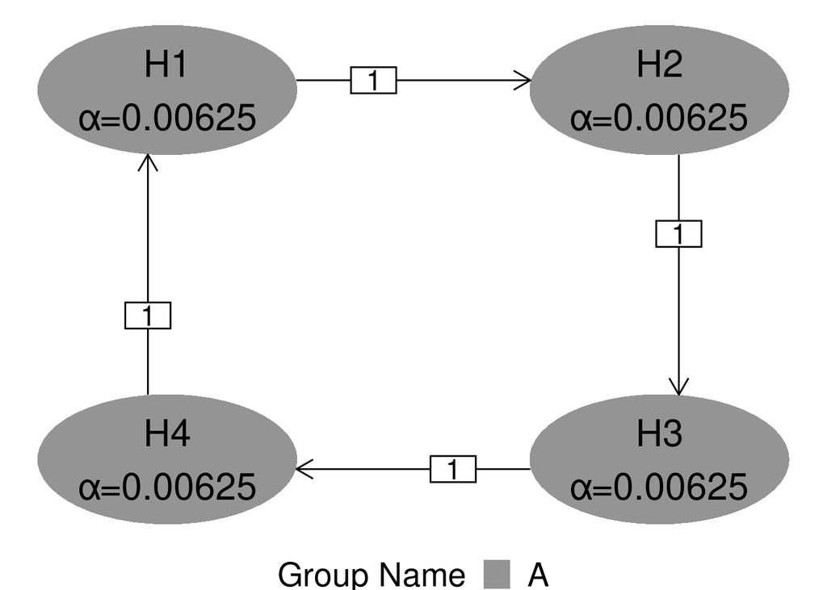

#### Graph 2

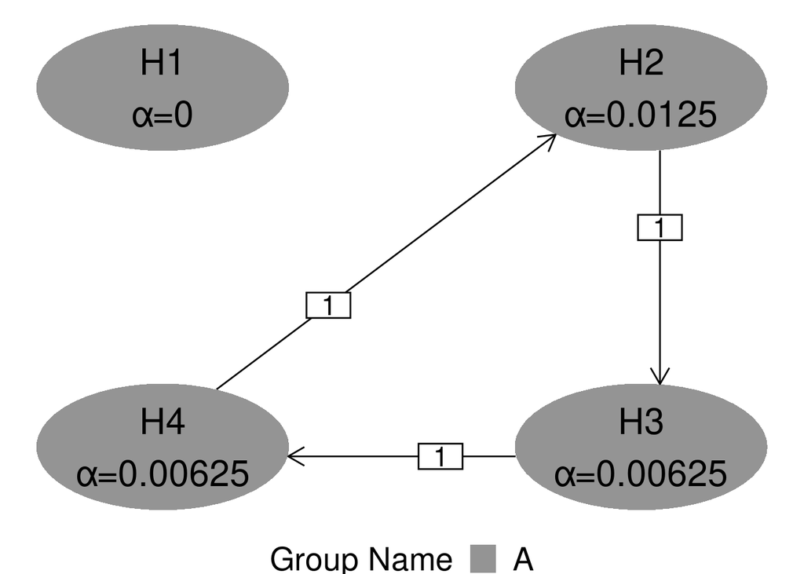

### Comparison of sequential p-values to multiplicity graphs

1. For rejected hypotheses, the maximum $\alpha$ allocated to the hypothesis.
2. The maximum $\alpha$ allocated to the non-rejected hypotheses; since each sequential p-value is greater than the allocated $\alpha$ for the corresponding hypothesis, none of these hypotheses were rejected.

```r
EOCtabx %>%
  select(c(1:3, 6, 4:5, 7)) %>%
  kable() %>%
  kable_styling()
```

| Name | Group | Sequential p | Max alpha allocated | Rejected | Adjusted p | Last Graph |
| --- | --- | --- | --- | --- | --- | --- |
| H1 | A | 0.0005301 | 0.00625 | TRUE | 0.0021205 | 1 |
| H2 | B | 1.0000000 | 0.01250 | FALSE | 1.0000000 | 2 |
| H3 | C | 1.0000000 | 0.00625 | FALSE | 1.0000000 | 2 |
| H4 | D | 1.0000000 | 0.00625 | FALSE | 1.0000000 | 2 |

### Bounds at final $\alpha$ allocated for group sequential tests

As a separate validation, we examine group sequential bounds for each hypothesis updated with 1) the maximum $\alpha$ allocated above, 2) the number of events at each analysis, and 3) the cumulative spending at each analysis above. The nominal p-value for at least one of the analyses performed for each rejected hypotheses should be less than or equal to the nominal p-value in the group sequential design. For each hypothesis not rejected, all nominal p-values are greater than the its corresponding bound. For hypotheses tested without a group sequential design, the nominal p-value for the test of that hypothesis can be compared to the maximum alpha allocated in the above table.

```r
for (i in 1:n_hypo) {
  cat("####", paste(nameHypotheses[i], " \n"))
  hresults <- inputResults %>% filter(Name == unique(inputResults$Name)[i])
  xx <- paste("Max alpha allocated from above table: ",
    as.character(EOCtab$lastAlpha[i]),
    sep = ""
  )
  d <- gsDlist[[i]]
  # If not group sequential for this hypothesis, print the max alpha allocated
  # and the nominal p-value
  if (is.null(d)) {
    cat("Maximum alpha allocated: ")
    cat(EOCtab$lastAlpha[i])
    cat("\n\n")
    cat("Nominal p-value for hypothesis test: ")
    cat(hresults$ObsPval)
    cat("\n\n")
  }
  # For group sequential tests, print max alpha allocated and
  # corresponding group sequential bounds
  if (!is.null(gsDlist[[i]])) {
    cat("Nominal p-values at each analysis for comparison to bounds in table below:\n\n")
    cat(hresults$ObsPval)
    cat("\n\n")
    # Get other info for current hypothesis
    events<-hresults$ObsEvnts
    length(events)<-d$k
    length(spendingTime)<-d$k
    n.I <- ifelse(is.na(events),d$n.I,events)
    usTime <- ifelse(is.na(spendingTime),d$timing,spendingTime)
    n.Imax <- max(d$n.I)
    # If no alpha allocated, just print text line to note this along with the 0 alpha allocated
    if (EOCtab$lastAlpha[i] == 0) {
      cat("Maximum alpha allocated: 0\n\n")
      cat("No testing required\n\n")
    }
    if (EOCtab$lastAlpha[i] > 0) {
      dupdate <- gsDesign::gsDesign(
        alpha = EOCtab$lastAlpha[i],
        k = d$k,
        n.I = n.I,
        usTime = usTime,
        maxn.IPlan = n.Imax,
        n.fix = d$n.fix,
        test.type = 1,
        sfu = d$upper$sf,
        sfupar = d$upper$param
      )
      tabl <- gsDesign::gsBoundSummary(dupdate,
        Nname = "Events",
        exclude = c(
          "B-value", "CP", "CP H1", "Spending",
          "~delta at bound", "P(Cross) if delta=0",
          "PP", "P(Cross) if delta=1"
        )
      )
      kable(tabl, caption = xx, row.names = FALSE) %>%
        kable_styling() %>%
        cat()
      cat("\n\n")
    }
  }
}
```

#### H1

Nominal p-values at each analysis for comparison to bounds in table below:

6e-04 6e-07

Max alpha allocated from above table: 0.00625

| Analysis | Value | Efficacy |
| --- | --- | --- |
| IA 1: 35% | Z | 4.4720 |
| Events: 80 | p (1-sided) | 0.0000 |
| IA 2: 48% | Z | 3.7728 |
| Events: 110 | p (1-sided) | 0.0001 |
| Final | Z | 2.4994 |
| Events: 229 | p (1-sided) | 0.0062 |

#### H2

Maximum alpha allocated: 0.0125

Nominal p-value for hypothesis test: 1

#### H3

Maximum alpha allocated: 0.00625

Nominal p-value for hypothesis test: 1

#### H4

Maximum alpha allocated: 0.00625

Nominal p-value for hypothesis test: 1

## Environment information

- Run date: 2022-11-15 13:49:10
- R version: R version 4.1.1 (2021-08-10)